# **CMU 16825 Learning for 3D Vision – Final Project**

## **Uncertainty-Aware Hybrid Rendering with Gaussian Splatting and NeRF for High-Fidelity Synthesis**

### Team 25 Patrick Chen *(Andrew ID: bochunc)*

# Abstract

Efficient 3D rendering often involves a trade-off between speed and quality. **3D Gaussian Splatting (GS)** offers fast rendering but lacks fine detail, while **NeRF** delivers high fidelity at a high computational cost. We propose an **uncertainty-aware hybrid rendering framework** that combines the strengths of both, selectively applying NeRF to uncertain regions identified via a lightweight U-Net or MLP predictor trained on GS-derived features. Our best-performing model, **Hybrid-MLP 50%**, achieves the highest SSIM score (**0.892**) and a PSNR of **24.75**, outperforming GS-only (SSIM: 0.819, PSNR: 22.23) and matching NeRF-only (SSIM: 0.891, PSNR: 24.76), while reducing the total rendering time to **0.668s**—faster than NeRF-only (**0.827s**) and the state-of-the-art SS Mip-NeRF (**0.864s**). Meanwhile, the **Hybrid-UNet 50%** model offers similarly high quality (SSIM: **0.892**, PSNR: **24.73**) with a slightly higher runtime of **0.673s**, showcasing the robustness of our framework across model choices. These results demonstrate that our hybrid approach delivers superior perceptual fidelity with reduced computational cost by leveraging NeRF only where needed.

- Introduction
- Related Work
- Method
- Neural Uncertainty Feature
- Qualitative Result
- Quantitative Result
- References

# Introduction

Rendering 3D scenes typically trades off between efficiency and visual quality. **Gaussian Splatting (GS)** achieves fast rendering speeds but tends to blur fine textures. On the other hand, **Neural Radiance Fields (NeRF)** provide photorealistic quality but are computationally expensive for high-resolution scenes. We aim to develop a **hybrid rendering pipeline** that selectively applies NeRF rendering only to visually uncertain regions, identified through **uncertainty prediction**. This approach combines the advantages of both methods: fast rendering speeds and high-fidelity output, overcoming the limitations faced by either method individually.

# Related Work

- **NeRF: Representing Scenes as Neural Radiance Fields for View Synthesis [1]**  
  Introduced novel view synthesis with high-quality results, but suffers from slow inference speed.
- **3D Gaussian Splatting for Real-Time Radiance Field Rendering [2]**  
  Enabled fast 3D scene rendering, but lost high-frequency texture details compared to NeRF.
- **SS Mip-NeRF: Supersampled Mip-NeRF [3]**  
  Enhanced Mip-NeRF’s detail preservation by combining cone-based rendering with supersampling for superior anti-aliasing.

Our project builds upon these works by integrating uncertainty estimation into hybrid rendering for improved trade-off.

# Method

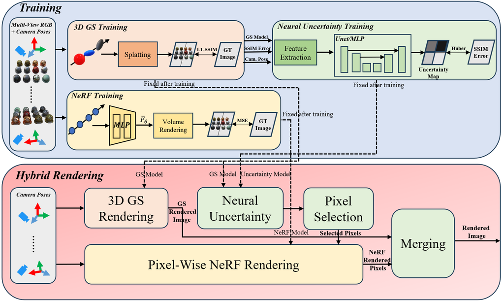

We propose an uncertainty-aware hybrid rendering framework that leverages the speed of 3D Gaussian Splatting (GS) and the fidelity of NeRF through uncertainty-guided pixel-wise refinement. As shown above figure, the framework consists of three stages:

**Training Phase:**

**(1) 3D GS Training:**  
A GS model is trained on multi-view RGB images and camera poses to enable efficient rendering and produce auxiliary features for uncertainty prediction. The training minimizes a perceptual loss that combines L1 and SSIM losses:

$$ \mathcal{L}_{\text{GS}} = \|I_{\text{pred}} - I_{\text{gt}}\|_1 + \lambda_{\text{SSIM}} \cdot (1 - \text{SSIM}(I_{\text{pred}}, I_{\text{gt}})), $$

where $\lambda_{\text{SSIM}}$ is a learnable weight and SSIM is computed over RGB channels.

**(2) NeRF Training:**  
A NeRF model is trained independently using the same inputs to generate high-fidelity volume renderings. The loss combines coarse and fine-level MSE losses:

$$ \mathcal{L}_{\text{NeRF}} = \begin{cases} \text{MSE}(I_{\text{coarse}}, I_{\text{gt}}), & \text{if epoch} < 100 \\ \alpha \cdot \text{MSE}(I_{\text{coarse}}, I_{\text{gt}}) + (1 - \alpha) \cdot \text{MSE}(I_{\text{fine}}, I_{\text{gt}}), & \text{otherwise} \end{cases} $$

with

$$ \alpha = \max\left(0.9 - \frac{\text{epoch} - 100}{\text{num\_epochs} - 100}, 0.5\right) $$

to gradually introduce fine supervision.

**(3) Uncertainty Model Training:**  
A lightweight U-Net or MLP is trained to predict per-pixel SSIM error from GS-rendered outputs. It uses four GS-derived features (alpha sum, color variance, view direction, 2D covariance area) and camera poses to produce a per-pixel uncertainty map. The training minimizes the smooth L1 (Huber) loss:

$$ \mathcal{L}_{\text{uncertainty}} = \text{Huber}(u_{\text{pred}}, u_{\text{target}}), $$

where $u_{\text{target}}$ is the SSIM error map and $u_{\text{pred}}$ is the model's prediction.

**Inference Phase:**

- **Input during Inference**:
  - A new camera pose is provided to the pipeline.
- **Steps during Inference**:

  (1). **GS Rendering**:
  - The GS model renders an initial full image and extracts GS feature maps.

  (2). **Uncertainty Prediction**:
  - The uncertainty model takes the GS feature maps and predicts an uncertainty score for each pixel.

  (3). **Pixel Selection**:
  - The top-k% most uncertain pixels are selected for refinement.

  (4). **NeRF Refinement**:
  - The NeRF model re-renders only the selected uncertain pixels based on the input camera pose.

  (5). **Merging**:
  - The final image is composed by combining GS-rendered pixels with NeRF-refined pixels at uncertain regions.

This hybrid approach allows the system to preserve the efficiency of GS while selectively enhancing critical regions using NeRF, achieving a balance between fast rendering and high visual quality.

# Neural Uncertainty Feature

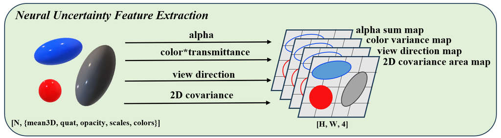

We extract four types of features from the GS model for uncertainty prediction. The input to the feature extraction consists of the output from the trained 3D Gaussian Splatting (GS) model, which includes the parameters of each 3D splat: 3D mean position, orientation quaternion, opacity (alpha), scales (radii), and RGB color values. These attributes are processed together with the known camera pose to generate per-pixel feature maps over the rendered image plane. To be more specific, a 2D Gaussian is represented by the following expression:

$$ f(x; \mu_i, \Sigma_i) = \frac{1}{2\pi \sqrt{|\Sigma_i|}} \exp\left( -\frac{1}{2} (x-\mu_i)^T \Sigma_i^{-1} (x-\mu_i) \right) $$

where:

- $x$ is a 2D vector that represents the pixel location
- $\mu_i$ is the 2D vector representing the mean of the $i$-th 2D Gaussian
- $\Sigma_i$ is the covariance of the 2D Gaussian

Given the opacity $o_i$ of a 3D Gaussian, the alpha value at pixel $x$ is computed as:

$$ \alpha_i(x) = o_i \exp\left(P(x,i)\right) $$

where

$$ P(x,i) = -\frac{1}{2} (x-\mu_i)^T \Sigma_i^{-1} (x-\mu_i) $$

Thus, $\alpha_i(x)$ represents the contribution of the $i$-th Gaussian to the pixel opacity at location $x$.

We extract the four feature maps as the following for training our uncertainty prediction model:

- **Alpha sum**: Measures the total accumulated opacity at each pixel.

  $$ \text{Alpha Sum}(x, y) = \sum_{i=1}^{N} \alpha_i(x, y) $$

  The alpha sum indicates the overall visibility along the viewing ray at a given pixel. Pixels with low accumulated opacity (e.g., transparent or sparsely covered regions) often suffer from high rendering uncertainty due to insufficient splat contributions. Conversely, very dense opacity could cause over-blending and loss of sharpness. Thus, alpha sum provides a strong signal for identifying uncertain regions.
- **Color variance**: Reflects the RGB variance of splat colors weighted by transmittance and opacity.

  $$ \text{Color Variance}(x, y) = \frac{1}{3} \sum_{c \in \{R,G,B\}} \left( \frac{ \sum_{i=1}^{N} w_i(x,y) (c_i(x,y) - \bar{c}(x,y))^2 }{ \sum_{i=1}^{N} w_i(x,y) } \right) $$

  where

  $$ w_i(x, y) = \alpha_i(x, y) \times \text{transmittance}_i(x, y), $$

  and

  $$ \bar{c}(x,y) = \frac{\sum_{i=1}^{N} w_i(x,y) \, c_i(x,y)}{\sum_{i=1}^{N} w_i(x,y)} $$

  Here, $\bar{c}(x,y)$ represents the weighted average color at pixel $(x,y)$, computed using the weights from opacity and transmittance. It serves as the local mean color, allowing us to measure how much each splat's color deviates from the expected average appearance at that pixel. A high deviation indicates the presence of multiple surfaces, lighting variations, or texture discontinuities, leading to greater uncertainty. Therefore, regions with large color variance are more likely to suffer from rendering errors and benefit from NeRF-based refinement.
- **2D covariance area**: Captures the average projected footprint size (area of splat spread).

  $$ \text{2D Covariance Area}(x, y) = \frac{ \sum_{i=1}^{N} \alpha_i(x, y) \det(\Sigma_i) }{ \sum_{i=1}^{N} \alpha_i(x, y) } $$

  where $\Sigma_i$ is the 2D covariance matrix of the $i$-th splat.

  The 2D covariance area measures how spread out the projected splats are on the image plane. Larger footprint areas imply a higher degree of depth uncertainty, motion blur, or blending between objects. Pixels associated with large projected areas tend to be more uncertain due to ambiguities in fine geometry or appearance, making this feature a reliable predictor of error-prone regions.
- **View direction cosine**: Represents the weighted cosine of the viewing angle.

  $$ \text{View Direction Cosine}(x, y) = \frac{ \sum_{i=1}^{N} \alpha_i(x, y) \cos(\theta_i) }{ \sum_{i=1}^{N} \alpha_i(x, y) } $$

  where $\theta_i$ is the angle between the camera viewing direction and the splat’s surface orientation.

  The view direction cosine quantifies how oblique the viewing angle is relative to the splat’s normal. Pixels viewed at grazing angles often exhibit foreshortening, lower surface visibility, and higher rendering distortion. As such, highly oblique view angles are strongly correlated with greater rendering uncertainty, making this an important geometric feature for uncertainty prediction.

These four feature maps, each of size $[H, W]$, totally $[H, W, 4]$, are fed into a neural network (MLP or UNet) to predict per-pixel SSIM-based uncertainty.

# Qualitative Results

### Dataset Introduction

We use the NeRF Synthetic Dataset, which consists of photorealistic scenes rendered from synthetic 3D assets. The dataset provides multi-view RGB images along with ground-truth camera poses for each scene. Both the training and validation sets contain 100 images and their corresponding camera poses, while the test set contains 200 images and camera poses. In our experiments, we focus on the "materials" scene.

In our framework, the input includes multi-view RGB images and their corresponding camera poses. The expected output is a high-quality rendered novel view, reconstructed using a hybrid rendering pipeline that combines 3D Gaussian Splatting and uncertainty-guided pixel-wise NeRF refinement.

For the following results, we compare two models for uncertainty prediction: a 110K-parameter U-Net achieving a Spearman correlation of 0.890, and a lightweight 1K-parameter two-layer MLP achieving a Spearman correlation of 0.756.

### Implemented Uncertainty Prediction Model: U-Net

The following table presents the hybrid rendering results using U-Net with 110K parameters for uncertainty prediction, where the top ( k% ) of pixels with the highest uncertainty are re-rendered using pixel-wise NeRF refinement.

Uncertainty Models

Camera View Index

Top k% Uncertainty Threshold

Ground-Truth Image

GS Prediction Image

NeRF Prediction Image

SSIM Error Map

Predicted Uncertainty

Mask After Top k% Thresholding

Hybrid Rendering Result

U-Net

0

k = 5

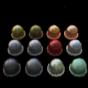

[figure not shown]

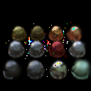

U-Net

0

k = 10

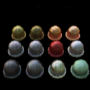

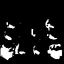

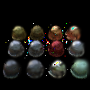

U-Net

0

k = 30

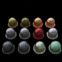

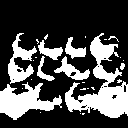

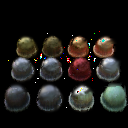

U-Net

0

k = 50

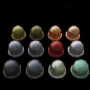

[figure not shown]

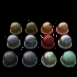

The following table shows the 360 degree reconstruction scene using the hybrid rendering with the proposed U-Net and top k% uncertained pixels selection:

Uncertainty Models

Top k% Uncertainty Threshold

GS Prediction GIF

NeRF Prediction GIF

Hybrid Rendering GIF

U-Net

k = 5

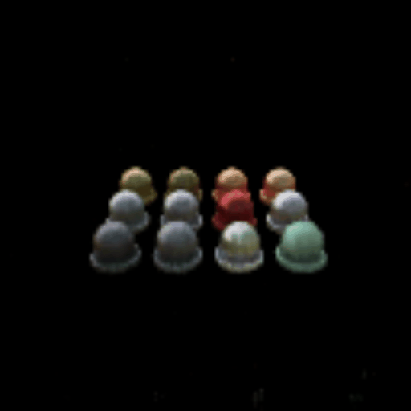

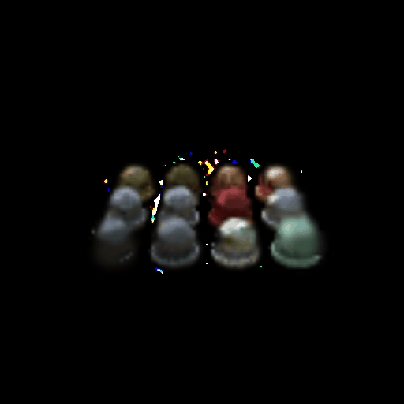

U-Net

k = 10

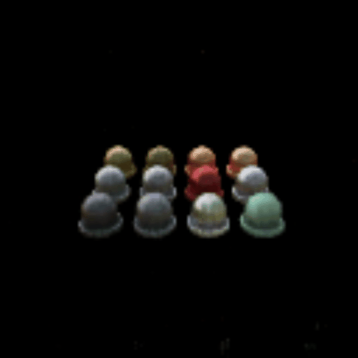

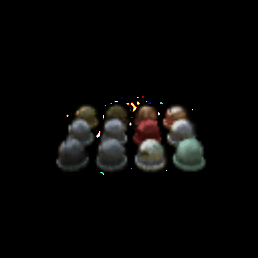

U-Net

k = 30

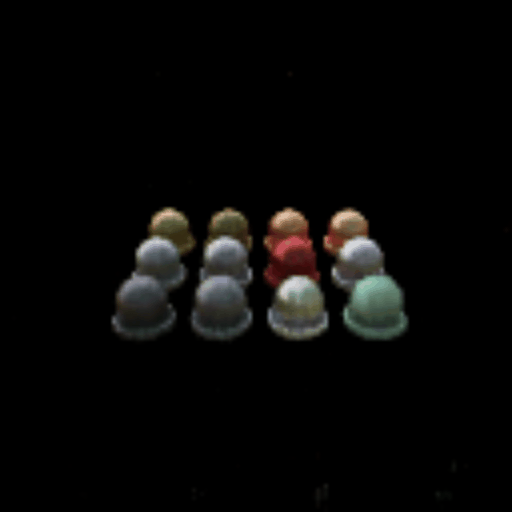

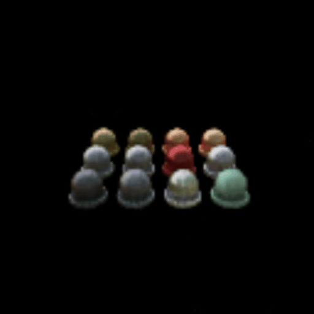

U-Net

k = 50

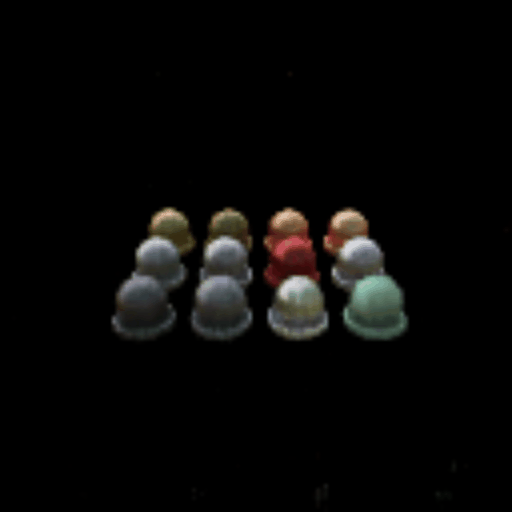

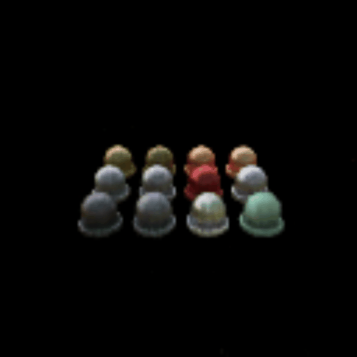

From the table above, we observe that when ( k = 30 ) and ( 50 ), the 360-degree reconstruction remains nearly identical to the full NeRF rendering. The hybrid results achieve comparable fidelity, while most of the pixels are still rendered by Gaussian Splatting. This demonstrates that only 30% or 50% of pixels need to be refined by NeRF to maintain high perceptual quality.